# About

## The Project

In this project, I explore the ratings of professors on campuses across America. All the code for data collection and analysis can be found on my academic [github](https://github.com/jonah-harvard/college-scraping). In this project, I look to determine if the distribution of ratings differs from college to college. I also look to see if the distribution of ratings correlates at all with the median salary of graduates of the college.

## The Data

The data that I am working with concern the ratings of professors across different colleges, and the median salaries of graduates of those colleges.

#### Rating Data

I wrote a [script in python](https://github.com/jonah-harvard/college-scraping/blob/master/scrape_rate_my_professor.py), that I use to collect professor rating data from [Rate My Professor](https://www.ratemyprofessors.com/). Some thought should be put in to whether the ratings are truly representative of the general student opinion of these teachers and readers should just keep in mind that it represents ratings as reported in this specific context. The first 10 professors (alphabetically) are shown below:

Professor Ratings

| Name | Rating | Difficulty | Department | College |
| --- | --- | --- | --- | --- |
| A.J. Hildebrand | 4.50 | 2.60 | Mathematics | University of Illinois at Urbana-Champaign |
| Adrian Randolph | 4.08 | 3.33 | Art History | Dartmouth College |
| Al Acres | 4.70 | 3.30 | Art History | Princeton University |
| Alan Bell | 4.37 | 3.13 | Science | Cornell University |
| Alan Grodzinsky | 4.30 | 3.50 | Engineering | Massachusetts Institute of Technology |
| Alan Kennedy | 4.50 | 2.43 | English | Carnegie Mellon University |
| Albert Meyer | 3.00 | 1.50 | Computer Science | Massachusetts Institute of Technology |
| Alex Flecker | 3.30 | 2.40 | Science | Cornell University |
| Alexander Beecroft | 3.80 | 2.40 | Literature | Yale University |
| Alexander Nehamas | 4.50 | 4.00 | Philosophy | Princeton University |

#### Salary Data

The data on median salaries after graduation comes from [Kaggle](https://www.kaggle.com/wsj/college-salaries) and was released by the Wall Street Journal. The data feature the median salary of graduates just after graduating and the median salary of graduates well into their careers. Below are the first 10 colleges.

Median Salaries by College

| School Name | School Type | Starting Median Salary | Mid-Career Median Salary | Mid-Career 10th Percentile Salary | Mid-Career 25th Percentile Salary | Mid-Career 75th Percentile Salary | Mid-Career 90th Percentile Salary |
| --- | --- | --- | --- | --- | --- | --- | --- |
| Massachusetts Institute of Technology (MIT) | Engineering | $72,200.00 | $126,000.00 | $76,800.00 | $99,200.00 | $168,000.00 | $220,000.00 |
| California Institute of Technology (CIT) | Engineering | $75,500.00 | $123,000.00 | N/A | $104,000.00 | $161,000.00 | N/A |
| Harvey Mudd College | Engineering | $71,800.00 | $122,000.00 | N/A | $96,000.00 | $180,000.00 | N/A |
| Worcester Polytechnic Institute (WPI) | Engineering | $61,000.00 | $114,000.00 | $80,000.00 | $91,200.00 | $137,000.00 | $180,000.00 |
| Carnegie Mellon University (CMU) | Engineering | $61,800.00 | $111,000.00 | $63,300.00 | $80,100.00 | $150,000.00 | $209,000.00 |
| Rensselaer Polytechnic Institute (RPI) | Engineering | $61,100.00 | $110,000.00 | $71,600.00 | $85,500.00 | $140,000.00 | $182,000.00 |
| Georgia Institute of Technology | Engineering | $58,300.00 | $106,000.00 | $67,200.00 | $85,200.00 | $137,000.00 | $183,000.00 |
| Colorado School of Mines | Engineering | $58,100.00 | $106,000.00 | $62,200.00 | $87,900.00 | $142,000.00 | $201,000.00 |
| Wentworth Institute of Technology | Engineering | $53,000.00 | $96,700.00 | $55,200.00 | $74,000.00 | $117,000.00 | $153,000.00 |
| Tennessee Technological University | Engineering | $46,200.00 | $80,000.00 | $42,100.00 | $62,600.00 | $99,500.00 | $121,000.00 |

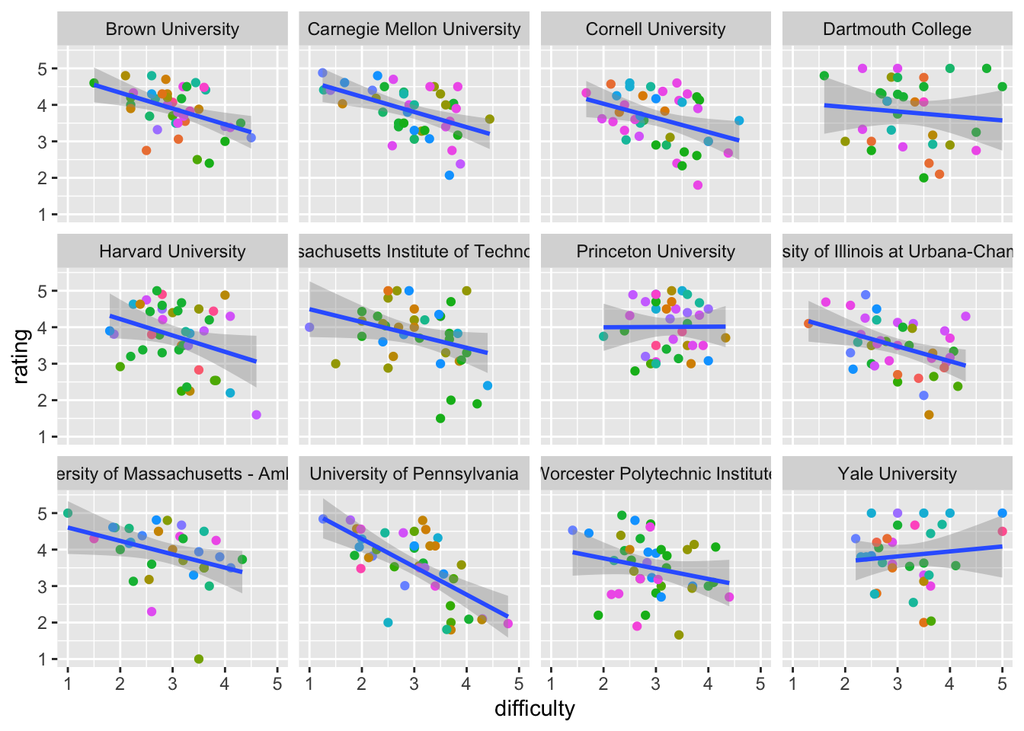

```
##
##  Pearson's product-moment correlation
##
## data:  carnegie_mellon$difficulty and carnegie_mellon$rating
## t = -3.4182, df = 38, p-value = 0.001517
## alternative hypothesis: true correlation is not equal to 0
## 95 percent confidence interval:
##  -0.6919236 -0.2042892
## sample estimates:
##        cor
## -0.4849381
```

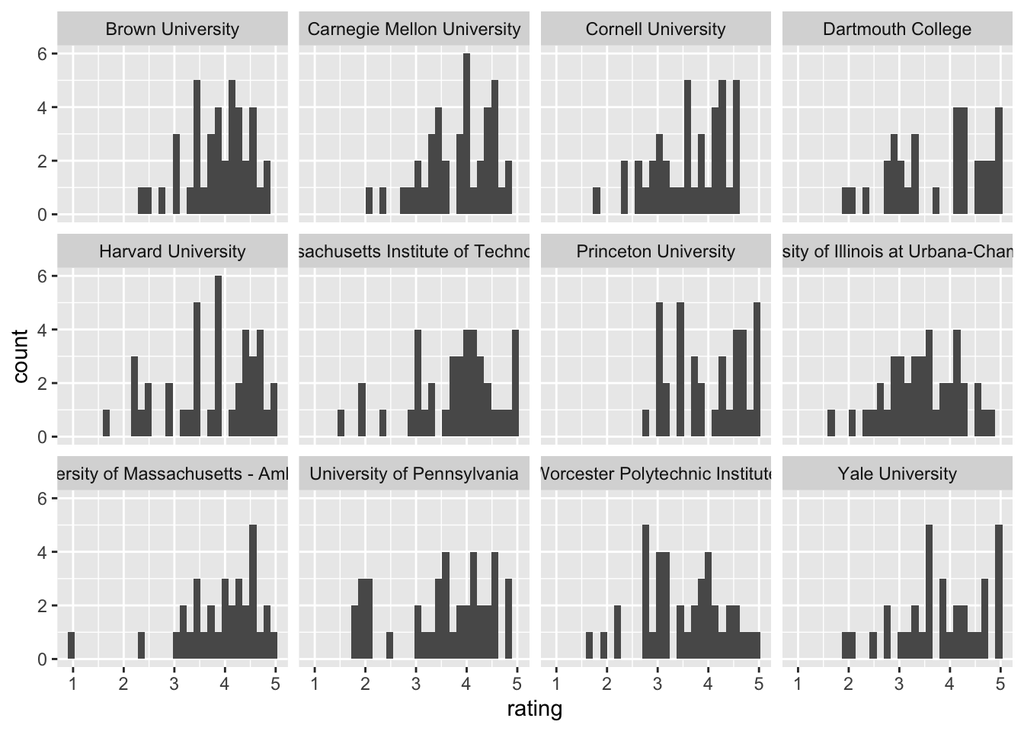

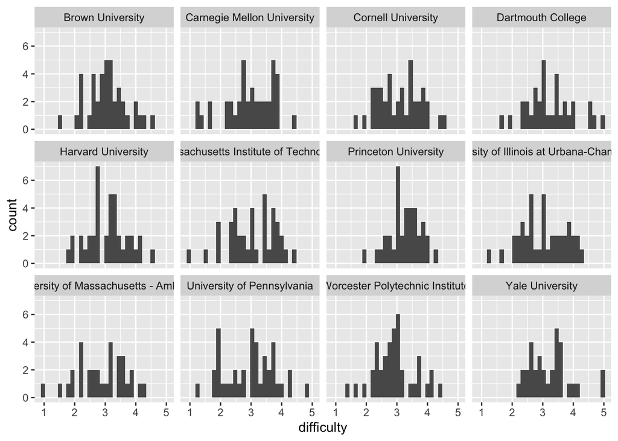